# EasyAovWlxPlot

### 多指标统计分析

#### 多个指标同时做正态检验和方差齐性分析(MuiNorCV)

这里对多组数据进行分析，正态检验和方差齐性结果我时用T或F代表，方便阅读。

- data：输入数据框，第一列为样本编号，第二列为分组，注意分组标签必须设定为group，第三列以后就是测定或者收集的指标了；
- num：代表您想要进行统计的列,这里可以输入多个列，只需要指定列号即可：例如：num = c(4:6)；
- method_cv：代表选择方差齐性的方法，有两种可供选择：method_cv == “bartlett.test” ;method_cv == “leveneTest”；

```r
dim(data_wt)
```

```
## [1] 12 12
```

```r
# ?MuiNorCV
# 使用案例
norCv = MuiNorCV(data = data_wt,num = c(4:10),method_cv = "leveneTest")
#展示正态检验和方差齐性结果
norCv
```

```
##      DI      cor     CV
## [1,] "AP"    "TRUE"  "TRUE"
## [2,] "bac"   "TRUE"  "TRUE"
## [3,] "fun"   "FALSE" "TRUE"
## [4,] "micro" "TRUE"  "TRUE"
## [5,] "NH4-N" "TRUE"  "TRUE"
## [6,] "NO3-N" "TRUE"  "TRUE"
## [7,] "pH"    "FALSE" "TRUE"
```

cor列是正态检验结果，TRUE就是符合正态分布，FALSE就是不符合

CV是指方差齐性分析结果，TURE为符合或者FALSE不符合。

```
    DI      cor     CV
[1,] "AP"    "TRUE"  "TRUE"
[2,] "bac"   "TRUE"  "TRUE"
[3,] "fun"   "FALSE" "TRUE"
[4,] "micro" "TRUE"  "TRUE"
[5,] "NH4-N" "TRUE"  "TRUE"
[6,] "NO3-N" "TRUE"  "TRUE"
```

#### 多个指标方差检验(MuiaovMcomper)

- data：输入数据框，第一列为样本编号，第二列为分组，注意分组标签必须设定为group，第三列以后就是你测定或者收集的指标
- num：代表您想要进行统计的列,这里可以输入多个列，只需要指定列号即可：例如：num = c(4:6)
- method_Mc：选择需要使用的多重比较方法，这里又多种方法可供选择：method_Mc == “LSD”;method_Mc == “SNK”;method_Mc == “Duncan”;method_Mc == “scheffe”

```r
# ? MuiaovMcomper
# #使用案例
result = MuiaovMcomper(data = data_wt, num = c(4:6), method_Mc = "Tukey")
#提取每个指标方差检验多重比较结果
result
```

```
##     AP bac fun
## CF  a   a   a
## CK   b  ab  a
## Rhi ab   b   b
## WT  ab  ab  a
```

结果展示：多个指标按照列排布。

```
  AP bac fun
CF  a   a   a
CK   b  ab  a
Rhi ab   b   b
WT  ab  ab  a
```

#### 多个指标非参数检验(MuiKwWlx)

- data：输入数据框，第一列为样本编号，第二列为分组，注意分组标签必须设定为group，第三列以后就是测定或者收集的指标了
- num：代表您想要进行统计的列,这里可以输入多个列，只需要指定列号即可：例如：num = c(4:6)

```r
# ? MuiKwWlx
# #使用案例
result = MuiKwWlx(data = data_wt,num = c(4:6))
#提取每个指标非参数检验多重比较结果
result
```

```
##     AP bac fun
## CF   a   a   a
## CK   a   a   a
## Rhi  a   a   a
## WT   a   a   a
```

非参数检验也是类似的结果展示方式。

#### 多组数据差异分析柱状图(MuiPlotresultBar)

我让该函数自动保存每个指标的出图文件到当前文件夹中。这些文件以该指标名称命名；

- data：输入数据框，第一列为样本编号，第二列为分组，注意分组标签必须设定为group，第三列以后就是测定或者收集的指标了
- num：代表您想要进行统计的列,这里可以输入多个列，只需要指定列号即可：例如：num = c(4:6)
- sig_show：代表差异展示方式；sig_show =“abc”是使用字母表示;sig_show =“line”是使用连线和星号表示；如果是NA，那么就不显示显著性结果
- result：代表显著性差异分析结果，是一个数据框，每一列是显著性标记字母,MuiKwWlx

```r
# ?MuiPlotresultBar
# # #使用案例
result = MuiKwWlx(data = data_wt, num = c(4:6))
result
```

```
##     AP bac fun
## CF   a   a   a
## CK   a   a   a
## Rhi  a   a   a
## WT   a   a   a
```

```r
# #结果直接输出到文件夹中
MuiPlotresultBar(data = data_wt,num = c(4:6),result = result ,sig_show ="line")
```

```
## [1] 4
```

```
## [1] 5
```

```
## [1] 6
```

这个函数并不展示图表，因为是批量出图，加入你要做几千个指标，我都把图表存起来，就太可怕的，所以我会在你当前工作路径下建立一个名为Muibar的文件夹，将图表全部输出到其中。

[figure not shown]

图3

#### 多组数据差异分析箱线图(MuiPlotresultBox)

我让该函数自动保存每个指标的出图文件到当前文件夹中。这些文件以该指标名称命名；

- data：输入数据框，第一列为样本编号，第二列为分组，注意分组标签必须设定为group，第三列以后就是妮妮测定或者收集的指标了
- num：代表您想要进行统计的列,这里可以输入多个列，只需要指定列号即可：例如：num = c(4:6)
- sig_show：代表差异展示方式；sig_show =“abc”是使用字母表示;sig_show =“line”是使用连线和星号表示；如果是NA，那么就不显示显著性结果
- result：代表显著性差异分析结果，是一个数据框，每一列是显著性标记字母,MuiKwWlx

```r
# ?MuiPlotresultBox
#使用案例
result = MuiKwWlx(data = data_wt,num = c(4:8))
result
```

```
##     AP bac fun micro NH4-N
## CF   a   a   a     a     a
## CK   a   a   a     a     a
## Rhi  a   a   a     a     a
## WT   a   a   a     a     a
```

```r
# #直接出图到文件夹中
MuiPlotresultBox(data = data_wt,num = c(4:8),result = result,sig_show ="abc")
```

```
## [1] 4
```

```
## [1] 5
```

```
## [1] 6
```

```
## [1] 7
```

```
## [1] 8
```

这个函数并不展示图表，因为是批量出图，加入你要做几千个指标，我都把图表存起来，就太可怕的，所以我会在你当前工作路径下建立一个名为Muibox的文件夹，将图表全部输出到其中。

[figure not shown]

图4

#### 差异结果分面柱状图(FacetMuiPlotresultBar)

单个图形的展示可能满足我们的要求，此时分面图形在补一刀

- data：输入数据框，第一列为样本编号，第二列为分组，注意分组标签必须设定为group，第三列以后就是妮妮测定或者收集的指标了
- num：代表您想要进行统计的列,这里可以输入多个列，只需要指定列号即可：例如：num = c(4:6)
- sig_show：代表差异展示方式；sig_show =“abc”是使用字母表示;sig_show =“line”是使用连线和星号表示；如果是NA，那么就不显示显著性结果
- result：代表显著性差异分析结果，是一个数据框，每一列是显著性标记字母,MuiKwWlx
- ncol:代表分面展示每一行放几张图

```r
# ?FacetMuiPlotresultBar
# # #使用案例
result = MuiaovMcomper(data = data_wt,num = c(4:10),method_Mc = "Tukey")
result
```

```
##     AP bac fun micro NH4-N NO3-N pH
## CF  a   a   a     a      a     b  b
## CK   b  ab  a     a      a     b a
## Rhi ab   b   b     b     a    a   b
## WT  ab  ab  a     ab     a     b  b
```

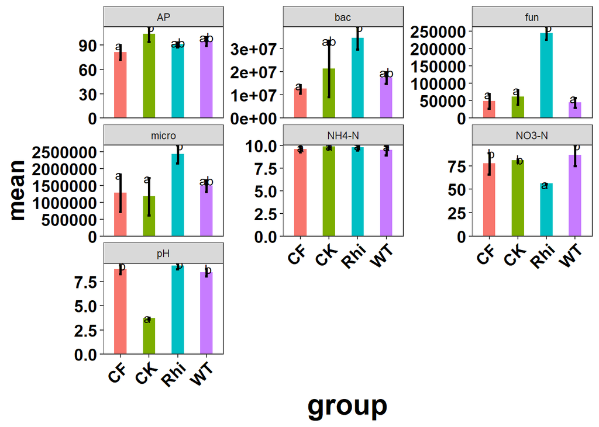

[figure not shown]

```r
result1 = FacetMuiPlotresultBar(data = data_wt,num = c(4:10),result = result,sig_show ="abc",ncol = 3)
result1[[1]]
```

#### 差异分面箱线图(FacetMuiPlotresultBox)

- data：输入数据框，第一列为样本编号，第二列为分组，注意分组标签必须设定为group，第三列以后就是妮妮测定或者收集的指标了
- num：代表您想要进行统计的列,这里可以输入多个列，只需要指定列号即可：例如：num = c(4:6)
- sig_show：代表差异展示方式；sig_show =“abc”是使用字母表示;sig_show =“line”是使用连线和星号表示；如果是NA，那么就不显示显著性结果
- result：代表显著性差异分析结果，是一个数据框，每一列是显著性标记字母,MuiKwWlx
- ncol:代表分面展示每一行放几张图

```r
# ?FacetMuiPlotresultBox
# #使用案例
result = MuiaovMcomper(data = data_wt,num = c(4:10),method_Mc = "Tukey")
result
```

```
##     AP bac fun micro NH4-N NO3-N pH
## CF  a   a   a     a      a     b  b
## CK   b  ab  a     a      a     b a
## Rhi ab   b   b     b     a    a   b
## WT  ab  ab  a     ab     a     b  b
```

```r
#
result1 = FacetMuiPlotresultBox(data = data_wt,num = c(4:10),result = result,sig_show ="abc",ncol = 2 )
```

```
## [1] 4
## [1] 5
## [1] 6
## [1] 7
## [1] 8
## [1] 9
## [1] 10
```

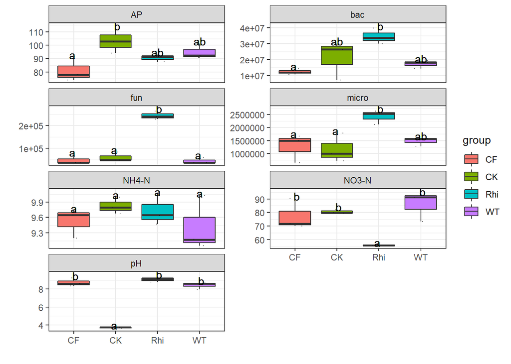

```r
result1[[1]] + theme_bw()
```

[figure not shown]

图6

### 单个指标一体化分析(SingleStat)

这个函数可以将我们的目标列做正态检验和方差齐性，然后根据结果选择方差检验或者多重比较方法，最后选择自己需要的出图方式和显著性标记方式展示。

- data：输入数据框，第一列为样本编号，第二列为分组，注意分组标签必须设定为group，第三列以后就是测定或者收集的指标了
- i：代表您想要进行统计的列，比如：第三列：i = 3
- method_Mc：选择需要使用的多重比较方法，这里又多种方法可供选择：method_Mc == “LSD”;method_Mc == “SNK”;method_Mc == “Duncan”;method_Mc == “scheffe”
- plot：可以选择需要的出图类型，柱状图和箱线图

```r
# ?SingleStat
# # #使用案例
# #输出结果第一个为图片，第二个是统计结果，第三个是统计方法
result = SingleStat(data = data_wt,plot = "bar",method_Mc = "Tukey",i= 4,sig_show ="abc")
```

```
## [1] "aov"
```

[figure not shown]

```r
# #导出图片
p = result[[1]]
p
```

[figure not shown]

图7

### 多个指标一体化分析(MuiStat)

实现了多个指标批量整体运行；这个函数可以将我们的目标列做正态检验和方差齐性，然后根据结果选择方差检验或者多重比较方法，最后选择自己需要的出图方式和显著性标记方式展示。

data：输入数据框，第一列为样本编号，第二列为分组，注意分组标签必须设定为group，第三列以后就是测定或者收集的指标了

num：代表您想要进行统计的列,这里可以输入多个列，只需要指定列号即可：例如：num = c(4:6)

method_cv：代表选择方差齐性的方法，有两种可供选择：method_cv == “bartlett.test” ;method_cv == “leveneTest”

method_Mc：选择需要使用的多重比较方法，这里又多种方法可供选择：method_Mc == “LSD”;method_Mc == “SNK”;method_Mc == “Duncan”;method_Mc == “scheffe”

plot：可以选择需要的出图类型，柱状图和箱线图

sig_show：代表差异展示方式；sig_show =“abc”是使用字母表示;sig_show =“line”是使用连线和星号表示；如果是NA，那么就不显示显著性结果

ncol：代表分面展示每一行放几张图

plottype：输出图形是分面展示plottype =mui，还是单张展示:plottype == “single”

```r
# ?MuiStat
#使用案例
result = MuiStat(data = data_wt,num = c(4:10),method_cv = "leveneTest",method_Mc = "Tukey",sig_show  = "abc",ncol = 4,plot = "box",plottype = "mui")
```

```
## [1] 4
## [1] 5
## [1] 7
## [1] 8
## [1] 9
## [1] 6
## [1] 10
```

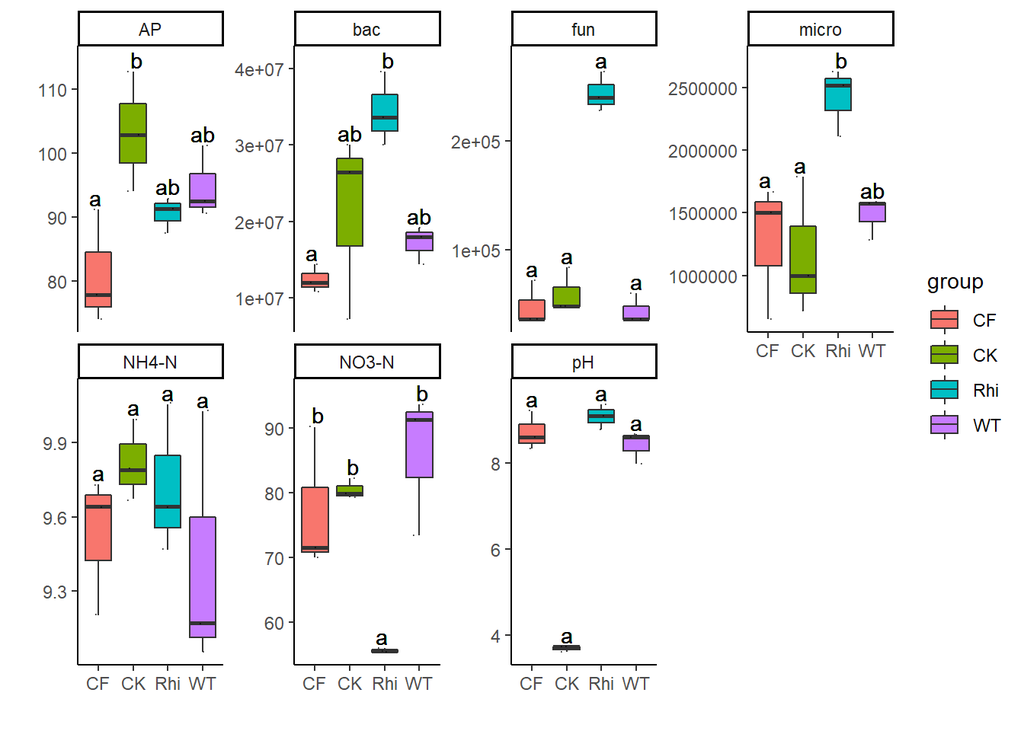

```r
result[[1]]
```

[figure not shown]

图8

作者：文涛 南京农业大学

责编：刘永鑫 中科院遗传发育所

## 写在后面

为鼓励读者交流、快速解决科研困难，我们建立了“宏基因组”专业讨论群，目前己有国内外5000+ 一线科研人员加入。参与讨论，获得专业解答，欢迎分享此文至朋友圈，并扫码加主编好友带你入群，务必备注“姓名-单位-研究方向-职称/年级”。技术问题寻求帮助，首先阅读[《如何优雅的提问》](http://mp.weixin.qq.com/s/H9gkepap0hy3NNskOkO44w)学习解决问题思路，仍末解决群内讨论，问题不私聊，帮助同行。

[figure not shown]

学习扩增子、宏基因组科研思路和分析实战，关注“宏基因组”

[figure not shown]

[figure not shown]

image

点击阅读原文，跳转最新文章目录阅读 https://mp.weixin.qq.com/s/5jQspEvH5_4Xmart22gjMA